# Assignment 3

SRILASYA GARIGIPATY

STUDENT # 100822953

DATA 1200 INTRODUCTION TO DATA ANALYSIS

ASSIGNMENT 3 NEURAL NETWORKS

```python
#Load Libraries
import pandas as pd
import numpy as np
import matplotlib.pyplot as plt
%matplotlib inline
import seaborn as sns
```

```python
#Load Data
data = pd.read_csv(r'C:\Users\Srilasya\Desktop\Data Science-Durham College\Introduction to Data Analysis-1200-02\Assignments\cancer.csv')
data.head()
```

|  | id | Clump Thickness | UofCSize | UofCShape | Marginal Adhesion | SECSize | Bare Nuclei | Bland Chromatin | Normal Nucleoli | Mitoses | Class |
| --- | --- | --- | --- | --- | --- | --- | --- | --- | --- | --- | --- |
| 0 | 1000025 | 5 | 1 | 1 | 1 | 2 | 1 | 3 | 1 | 1 | 2 |
| 1 | 1002945 | 5 | 4 | 4 | 5 | 7 | 10 | 3 | 2 | 1 | 2 |
| 2 | 1015425 | 3 | 1 | 1 | 1 | 2 | 2 | 3 | 1 | 1 | 2 |
| 3 | 1016277 | 6 | 8 | 8 | 1 | 3 | 4 | 3 | 7 | 1 | 2 |
| 4 | 1017023 | 4 | 1 | 1 | 3 | 2 | 1 | 3 | 1 | 1 | 2 |

```python
#Drop "id" column from data
data=data.drop("id",axis=1)
data.head()
```

|  | Clump Thickness | UofCSize | UofCShape | Marginal Adhesion | SECSize | Bare Nuclei | Bland Chromatin | Normal Nucleoli | Mitoses | Class |
| --- | --- | --- | --- | --- | --- | --- | --- | --- | --- | --- |
| 0 | 5 | 1 | 1 | 1 | 2 | 1 | 3 | 1 | 1 | 2 |
| 1 | 5 | 4 | 4 | 5 | 7 | 10 | 3 | 2 | 1 | 2 |
| 2 | 3 | 1 | 1 | 1 | 2 | 2 | 3 | 1 | 1 | 2 |
| 3 | 6 | 8 | 8 | 1 | 3 | 4 | 3 | 7 | 1 | 2 |
| 4 | 4 | 1 | 1 | 3 | 2 | 1 | 3 | 1 | 1 | 2 |

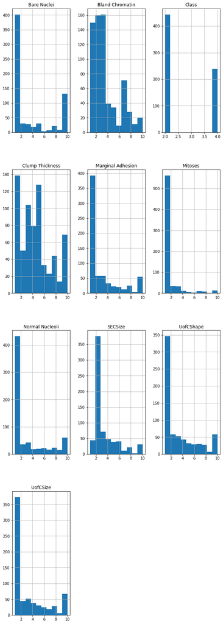

```python
#Visualisation of the distribution of the variables in dataset
data.hist(figsize=(10,30))
plt.show()
```

```python
#correlation between independent variables and dependent variable
data.corr()
```

|  | Clump Thickness | UofCSize | UofCShape | Marginal Adhesion | SECSize | Bare Nuclei | Bland Chromatin | Normal Nucleoli | Mitoses | Class |
| --- | --- | --- | --- | --- | --- | --- | --- | --- | --- | --- |
| Clump Thickness | 1.000000 | 0.642481 | 0.653470 | 0.487829 | 0.523596 | 0.593091 | 0.553742 | 0.534066 | 0.350957 | 0.714790 |
| UofCSize | 0.642481 | 1.000000 | 0.907228 | 0.706977 | 0.753544 | 0.691709 | 0.755559 | 0.719346 | 0.460755 | 0.820801 |
| UofCShape | 0.653470 | 0.907228 | 1.000000 | 0.685948 | 0.722462 | 0.713878 | 0.735344 | 0.717963 | 0.441258 | 0.821891 |
| Marginal Adhesion | 0.487829 | 0.706977 | 0.685948 | 1.000000 | 0.594548 | 0.670648 | 0.668567 | 0.603121 | 0.418898 | 0.706294 |
| SECSize | 0.523596 | 0.753544 | 0.722462 | 0.594548 | 1.000000 | 0.585716 | 0.618128 | 0.628926 | 0.480583 | 0.690958 |
| Bare Nuclei | 0.593091 | 0.691709 | 0.713878 | 0.670648 | 0.585716 | 1.000000 | 0.680615 | 0.584280 | 0.339210 | 0.822696 |
| Bland Chromatin | 0.553742 | 0.755559 | 0.735344 | 0.668567 | 0.618128 | 0.680615 | 1.000000 | 0.665602 | 0.346011 | 0.758228 |
| Normal Nucleoli | 0.534066 | 0.719346 | 0.717963 | 0.603121 | 0.628926 | 0.584280 | 0.665602 | 1.000000 | 0.433757 | 0.718677 |
| Mitoses | 0.350957 | 0.460755 | 0.441258 | 0.418898 | 0.480583 | 0.339210 | 0.346011 | 0.433757 | 1.000000 | 0.423448 |
| Class | 0.714790 | 0.820801 | 0.821891 | 0.706294 | 0.690958 | 0.822696 | 0.758228 | 0.718677 | 0.423448 | 1.000000 |

```python
#Identify number of Classes (i.e. Species)
data.Class.unique()
```

```
array([2, 4], dtype=int64)
```

```python
#information about dataset, checking datatype and if there are any null values in each column
data.info()
```

```
<class 'pandas.core.frame.DataFrame'>
RangeIndex: 683 entries, 0 to 682
Data columns (total 10 columns):
 #   Column             Non-Null Count  Dtype
---  ------             --------------  -----
 0   Clump Thickness    683 non-null    int64
 1   UofCSize           683 non-null    int64
 2   UofCShape          683 non-null    int64
 3   Marginal Adhesion  683 non-null    int64
 4   SECSize            683 non-null    int64
 5   Bare Nuclei        683 non-null    int64
 6   Bland Chromatin    683 non-null    int64
 7   Normal Nucleoli    683 non-null    int64
 8   Mitoses            683 non-null    int64
 9   Class              683 non-null    int64
dtypes: int64(10)
memory usage: 53.5 KB
```

```python
#columns names
data.columns
```

```
Index(['Clump Thickness', 'UofCSize', 'UofCShape', 'Marginal Adhesion',
       'SECSize', 'Bare Nuclei', 'Bland Chromatin', 'Normal Nucleoli',
       'Mitoses', 'Class'],
      dtype='object')
```

```python
#Key Statistics about the cancer data
data.describe()
```

|  | Clump Thickness | UofCSize | UofCShape | Marginal Adhesion | SECSize | Bare Nuclei | Bland Chromatin | Normal Nucleoli | Mitoses | Class |
| --- | --- | --- | --- | --- | --- | --- | --- | --- | --- | --- |
| count | 683.000000 | 683.000000 | 683.000000 | 683.000000 | 683.000000 | 683.000000 | 683.000000 | 683.000000 | 683.000000 | 683.000000 |
| mean | 4.442167 | 3.150805 | 3.215227 | 2.830161 | 3.234261 | 3.544656 | 3.445095 | 2.869693 | 1.603221 | 2.699854 |
| std | 2.820761 | 3.065145 | 2.988581 | 2.864562 | 2.223085 | 3.643857 | 2.449697 | 3.052666 | 1.732674 | 0.954592 |
| min | 1.000000 | 1.000000 | 1.000000 | 1.000000 | 1.000000 | 1.000000 | 1.000000 | 1.000000 | 1.000000 | 2.000000 |
| 25% | 2.000000 | 1.000000 | 1.000000 | 1.000000 | 2.000000 | 1.000000 | 2.000000 | 1.000000 | 1.000000 | 2.000000 |
| 50% | 4.000000 | 1.000000 | 1.000000 | 1.000000 | 2.000000 | 1.000000 | 3.000000 | 1.000000 | 1.000000 | 2.000000 |
| 75% | 6.000000 | 5.000000 | 5.000000 | 4.000000 | 4.000000 | 6.000000 | 5.000000 | 4.000000 | 1.000000 | 4.000000 |
| max | 10.000000 | 10.000000 | 10.000000 | 10.000000 | 10.000000 | 10.000000 | 10.000000 | 10.000000 | 10.000000 | 4.000000 |

### Setting up the dataset for predictive modeling using multi-layer perceptron model of a neural network

```python
#Create x and y variables
X = data.drop('Class',axis=1).to_numpy()
y = data['Class'].to_numpy()

#Create Train and Test datasets
from sklearn.model_selection import train_test_split
X_train, X_test, y_train, y_test = train_test_split(X, y, stratify=y,test_size = 0.20,random_state=100)

#Scale the data
from sklearn.preprocessing import StandardScaler
sc = StandardScaler()
x_train2 = sc.fit_transform(X_train)
x_test2 = sc.transform(X_test)
```

```python
#Script for Neural Network
from sklearn.neural_network import MLPClassifier
mlp = MLPClassifier(hidden_layer_sizes=(9,4,2),
                    activation='relu',solver='adam',
                    max_iter=10000,random_state=100)
mlp.fit(x_train2, y_train)
predictions = mlp.predict(x_test2)

#Evaluation Report and Matrix
from sklearn.metrics import classification_report, confusion_matrix
print(confusion_matrix(y_test,predictions))
print(classification_report(y_test,predictions))
```

```
[[88  1]
 [ 3 45]]
              precision    recall  f1-score   support

           2       0.97      0.99      0.98        89
           4       0.98      0.94      0.96        48

    accuracy                           0.97       137
   macro avg       0.97      0.96      0.97       137
weighted avg       0.97      0.97      0.97       137
```

from the confusion matrix it can be noted that there are 3+1=4 total wrong predictions out of 137 test data cancer class("2" for benign, "4" for malignant) using multi-layer perceptron model of a neural network

```python
#Forecast Table
predict2 = predictions.T
diff = predict2-y_test
FcstTble=pd.DataFrame({'Actual':y_test,'Predicted':predict2.round(2),'Difference':diff.round(2)})
print('\nForecast Table')
FcstTble.head(10)
```

```
Forecast Table
```

|  | Actual | Predicted | Difference |
| --- | --- | --- | --- |
| 0 | 2 | 2 | 0 |
| 1 | 4 | 4 | 0 |
| 2 | 2 | 2 | 0 |
| 3 | 4 | 4 | 0 |
| 4 | 2 | 2 | 0 |
| 5 | 2 | 2 | 0 |
| 6 | 4 | 4 | 0 |
| 7 | 2 | 2 | 0 |
| 8 | 2 | 2 | 0 |
| 9 | 2 | 2 | 0 |

```python
# Finding the predictions that went wrong in the Class feature using the multi-layer perceptron model of a neural network
indices = [i for i in range(len(y_test)) if y_test[i] != predictions[i]]
wrong_predictions = data.iloc[indices,:]
wrong_predictions
```

|  | Clump Thickness | UofCSize | UofCShape | Marginal Adhesion | SECSize | Bare Nuclei | Bland Chromatin | Normal Nucleoli | Mitoses | Class |
| --- | --- | --- | --- | --- | --- | --- | --- | --- | --- | --- |
| 32 | 2 | 1 | 1 | 2 | 2 | 1 | 3 | 1 | 1 | 2 |
| 42 | 10 | 10 | 10 | 4 | 8 | 1 | 8 | 10 | 1 | 4 |
| 51 | 5 | 5 | 5 | 8 | 10 | 8 | 7 | 3 | 7 | 4 |
| 116 | 1 | 1 | 1 | 1 | 4 | 3 | 1 | 1 | 1 | 2 |

### Method to see if performance of model will increase using various strategies.

```python
#Method 1: Increase Hidden Layers
#Script for Neural Network
from sklearn.neural_network import MLPClassifier
mlp = MLPClassifier(hidden_layer_sizes=(9,5,2),
                    activation='relu',solver='adam',
                    max_iter=10000,random_state=100)
mlp.fit(x_train2, y_train)
predictions = mlp.predict(x_test2)

#Evaluation Report and Matrix
from sklearn.metrics import classification_report, confusion_matrix
print(confusion_matrix(y_test,predictions))
print(classification_report(y_test,predictions))
```

```
[[88  1]
 [ 4 44]]
              precision    recall  f1-score   support

           2       0.96      0.99      0.97        89
           4       0.98      0.92      0.95        48

    accuracy                           0.96       137
   macro avg       0.97      0.95      0.96       137
weighted avg       0.96      0.96      0.96       137
```

### Classification and Regression Trees or CART for short refers to Decision Tree algorithms that can be used for classification or regression predictive modeling

```python
#Script for Decision Tree
from sklearn.tree import DecisionTreeClassifier

for name,method in [('DT', DecisionTreeClassifier(random_state=100))]:
    method.fit(x_train2,y_train)
    predict = method.predict(x_test2)
    print('\nEstimator: {}'.format(name))
    print(confusion_matrix(y_test,predict))
    print(classification_report(y_test,predict))
```

```
Estimator: DT
[[88  1]
 [ 4 44]]
              precision    recall  f1-score   support

           2       0.96      0.99      0.97        89
           4       0.98      0.92      0.95        48

    accuracy                           0.96       137
   macro avg       0.97      0.95      0.96       137
weighted avg       0.96      0.96      0.96       137
```

From the confusion matrix it can be noted that there are 4+1=5 total wrong predictions out of 137 test data cancer class("2" for benign, "4" for malignant) using Classification and Regression Trees or CART( Decision Tree algorithms )

```python
#Forecast Table
predict2 = predict.T
diff = predict2-y_test
FcstTble=pd.DataFrame({'Actual':y_test,'Predicted':predict2.round(2),'Difference':diff.round(2)})
print('\nForecast Table')
FcstTble.head()
```

```
Forecast Table
```

|  | Actual | Predicted | Difference |
| --- | --- | --- | --- |
| 0 | 2 | 2 | 0 |
| 1 | 4 | 4 | 0 |
| 2 | 2 | 2 | 0 |
| 3 | 4 | 4 | 0 |
| 4 | 2 | 2 | 0 |

```python
# Finding the predictions that went wrong in the Class- Target feature using the Decision Tree Algorithm
indices = [i for i in range(len(y_test)) if y_test[i] != predict[i]]
wrong_predictions = data.iloc[indices,:]
wrong_predictions
```

|  | Clump Thickness | UofCSize | UofCShape | Marginal Adhesion | SECSize | Bare Nuclei | Bland Chromatin | Normal Nucleoli | Mitoses | Class |
| --- | --- | --- | --- | --- | --- | --- | --- | --- | --- | --- |
| 22 | 3 | 1 | 1 | 1 | 2 | 1 | 2 | 1 | 1 | 2 |
| 42 | 10 | 10 | 10 | 4 | 8 | 1 | 8 | 10 | 1 | 4 |
| 91 | 1 | 1 | 1 | 1 | 2 | 1 | 2 | 1 | 1 | 2 |
| 103 | 7 | 3 | 4 | 4 | 3 | 3 | 3 | 2 | 7 | 4 |
| 124 | 7 | 5 | 3 | 7 | 4 | 10 | 7 | 5 | 5 | 4 |

## 2.Summary of Key Findings

### a. State and Explain Key Statisitcs of Dataset

Introduction: A dataset cancer was given which has 683 rows and 10 columns (independent variables) : 'Clump Thickness', 'UofCSize', 'UofCShape', 'Marginal Adhesion', 'SECSize', 'Bare Nuclei', 'Bland Chromatin', 'Normal Nucleoli' 'Mitoses', 'Class'. The dependent variable was the Class of cancer( 2 for benign and 4 for malignant)

In this assignment, an analysis of multi-layer perceptron model of a neural network algorithm was done to develop insights that can be used to create a machine learning model. The following concepts were applied in the exploratory data analysis: key statistics, correlation analysis, Neural network and decision tree analysis and evaluation of the models to determine if it is a good fit to the cancer data.

Key Statistics: The following Python libraries were imported to do the analysis: Pandas, Numpy, Mathplotlib. and Seaborn.

### b.State and Explain Final Algorithm

Multi Layer Perceptron Model

The multilayer perceptron model is a type of neural networking model that matches relevant inputs with related outputs. It is comprised of numerous layers of nodes. The input node is different from the other nodes and can be thought of as neuron, or processing core, with a specific activation function.. The multilayer perceptron model is capable of distinguishing data that is not separable in a linear way. The multilayer perceptron model uses the uses backpropagation algorithm that can be seen in a standard neural network. Multilayer perceptron’s can be found as part of the standard analysis algorithm for pattern recognition processes.

The output of ReLu is the maximum value between zero and the input value.An output is equal to zero when the input value is negative and the input value when the input is positive.

Bias is also added to the perceptron, which prevents all inputs from becoming equal to zero.

The final algorithm of the multi layer perceptron neural network model showed the following results:

Accuracy: Accuracy is the ratio of correct predictions to total predictions made. In MLP model, accuracy was 97%.

Precision: Precision is how accurate your model is . In MLP model, 97% of Class 2 benign cancers were correctly predicted, and 98% of Class 4 malignant cancers were correctly predicted. Overall precision is 97%.

Recall: Recall is the ratio of correctly predicted positive observations to all observations in actual class. In MLP model, Class 2 benign cancer can be correctly predicted 99% of the time. Class 4 malignant cancers can be correctly predicted 94% of the time. Overall recall is 96%

F1 score: F1 Score is the weighted average of Precision and Recall. In MLP model case, 97% is the F1 score. The confusion matrix that MLP neural network misclassified four cancer tumors out of 137 tumor test data the MLP neural network was predicted on.

The confusion matrix that MLP neural network misclassified four cancer tumors out of 137 tumor test data the MLP neural network was predicted on.

Classification and Regression Trees or CART

CART for short refers to Decision Tree algorithms that can be used for classification or regression predictive modeling. A node represents a single input variable (X) and a split point on that variable. Leaf nodes (also called terminal nodes) of the tree contain an output variable (y) which is used to make a prediction. In the decision tree cancer model, a train size of 80%,test size of 20% was used.

The final algorithm of CART Decision tree model showed the following results:

Accuracy: Accuracy is the ratio of correct predictions to total predictions made. In CART model, accuracy was 96%.

Precision: Precision is how accurate your model is. In CART model, 96% of Class 2 benign cancers were correctly predicted, and 98% of Class 4 malignant cancers were correctly predicted. Overall precision is 97%.

Recall: Recall is the ratio of correctly predicted positive observations to all observations in actual class. In CART model, Class 2 benign cancer can be correctly predicted 99% of the time. Class 4 malignant cancers can be correctly predicted 92% of the time. Overall recall is 95%

F1 score: F1 Score is the weighted average of Precision and Recall. In CART model case, 96% is the F1 score. The confusion matrix that CART Decision tree misclassified 5 cancer tumors out of 137 tumor test data decision tree model was predicted on.

The confusion matrix that CART Decision tree misclassified 5 cancer tumors out of 137 tumor test data decision tree model was predicted on.

### c.Evaluate the Algorithm

MLP Neural model

Precision can be described as the fraction of times that the model classifies the number of cases correctly. It is a measure of confirmation, and it indicates how often the model is correct. Overall precision is 97%, which indicates a good model.

Recall identifies how many patients were correctly classed into benign or malignant cancer classes in their particular class. Overall recall was 96% which indicates majority of the data was classified correctly for each class.

Both scores combine to make the F1 score. The F1 score is the weighted mean of precision. Overall F1 score is 97 % which indicates a good model with low numbers of false positive and false negative predictions.

CART Decision Tree model

Precision can be described as the fraction of times that the model classifies the number of cases correctly. It is a measure of confirmation, and it indicates how often the model is correct. Overall precision is 97%, which indicates a good model.

Recall identifies how many patients were correctly classed into benign or malignant cancer classes in their particular class. Overall recall was 95% which indicates majority of the data was classified correctly for each class.

Both scores combine to make the F1 score. The F1 score is the weighted mean of precision and recall. Overall F1 score is 96 % which indicates a good model with low numbers of false positive and false negative predictions.

[figure not shown]

## 3.Identify 3 ways to Improve Performance of Model

1.Feature Selection-removing features in order to improve model performance. feature selection can be done on a neural network through creating a decision tree model. Decision trees are a separate type of machine learning model. Decision trees are useful as they can calculate and rank the most important featuresbased on various statistical criteria. We can first fit the data using the decision tree, and then use the output from the decision tree to remove features that are deemed unimportant, before providing the reduced dataset to our neural network.

2.Regularization - is a technique which helps to reduce overfitting in a neural network. When we add regularization to network, we add a new regularization term, and the loss function is modified.Dropout regularization is another regularization technique in which certain neurons are dropped along with their connections present in the neural network. Dropout regularization prohibits the neurons from relying only on certain features, and weights are spread out amongst all the inputs. The network uses all the input features to determine the output and does not rely on any single one, thus improving the neural network model.

Ensemble of Algorithms-If individual neural networks are not as accurate as benchmark that is ideal, method of emsemble is when various neural networks are combined to increase predictive power. Different neural network architectures can be used, and train the various neural networks on on different parts of the data and ensemble them and use their collective predictive power to get high accuracy on test data.

## References

DATA 1200 WEEK 6 NOTES ON NEURAL NETWORK AND DECISION TREE

https://towardsdatascience.com/improving-deep-neural-networks-b5984e29e336

BOOK- Neural Network Projects with Python Author:James Loy

BOOK- Neural Networks: A Practical Guide for Understanding and Programming Neural Networks and Useful Insights for Inspiring Reinvention Author: Steven Cooper